# Exercise 1

# Exercise 1

```
Default probaility in whole dataset:  0.199496644295302
```

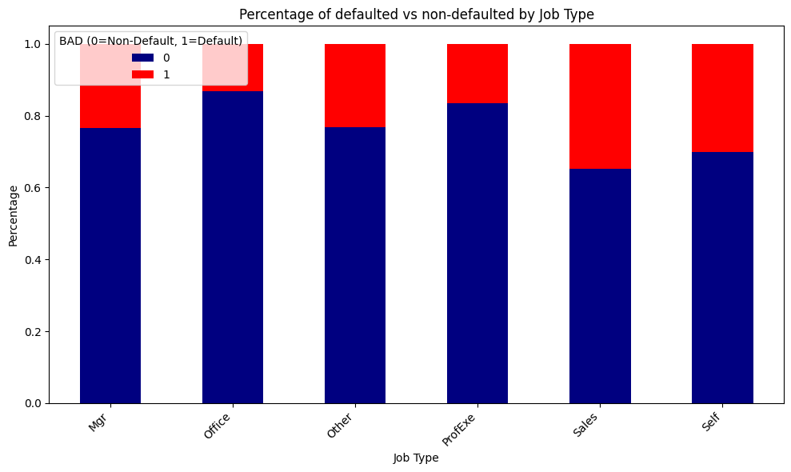

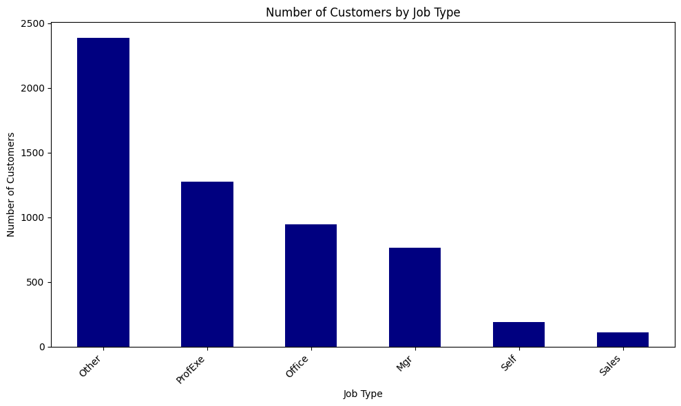

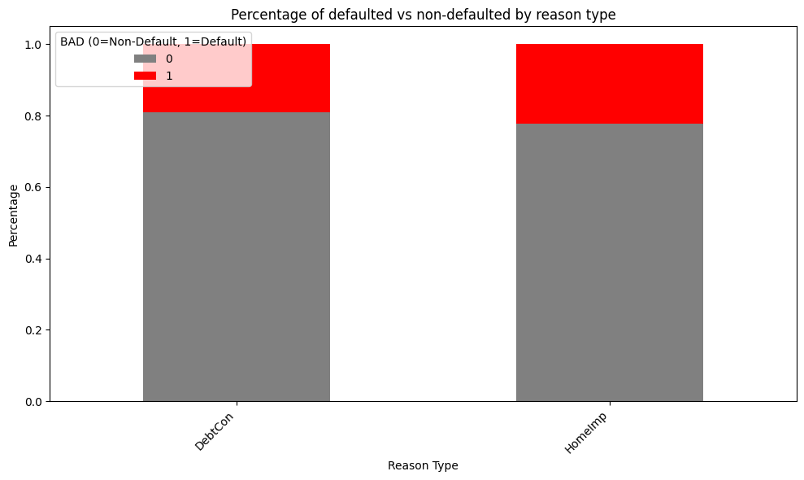

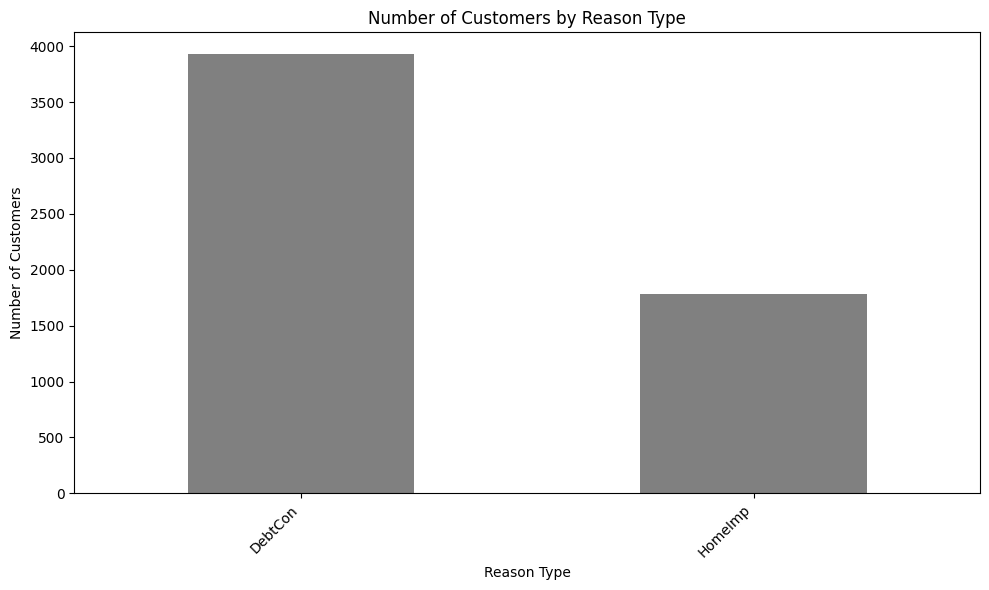

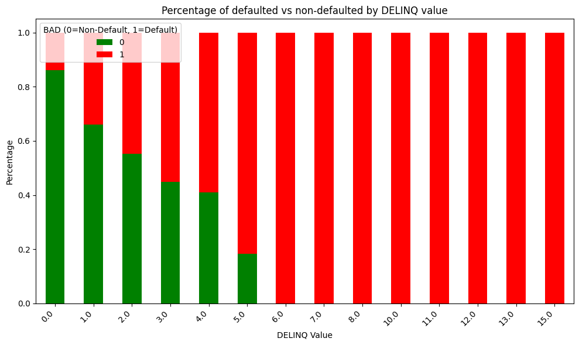

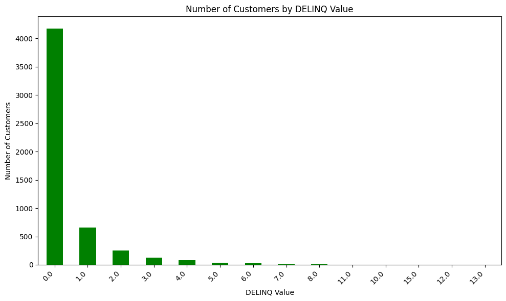

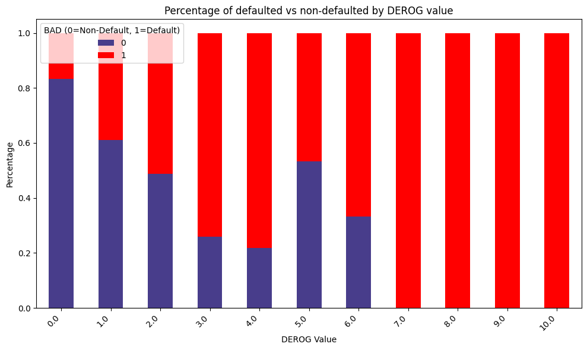

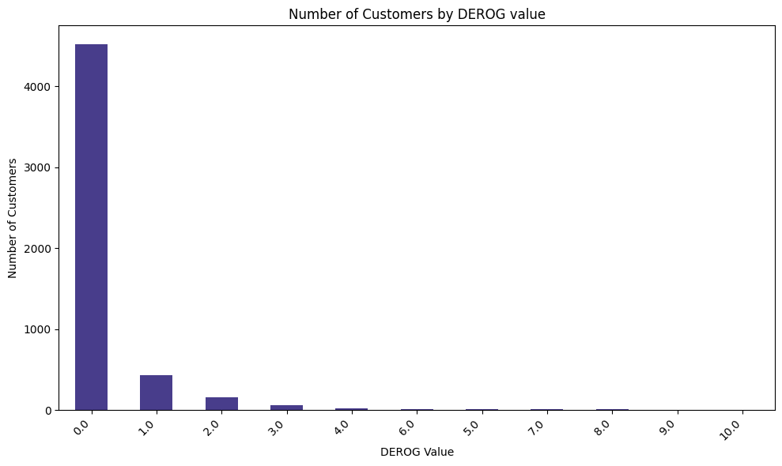

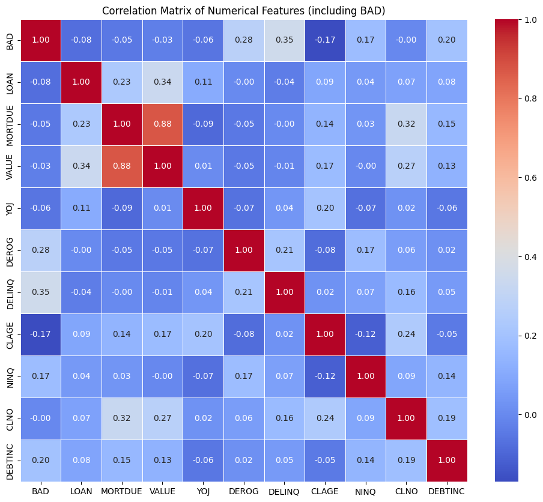

```python
# Exercise 1
# a) Default probability whole dataset

default = data[data['BAD'] == 1]
non_default = data[data['BAD'] == 0]
prob_default_dataset = len(default) / len(data)

print("Default probaility in whole dataset: ", prob_default_dataset)



# b) Job Type

job_bad_counts = data.groupby(['JOB', 'BAD']).size().unstack(fill_value=0)
job_bad_percentages = job_bad_counts.apply(lambda x: x / x.sum(), axis=1)

fig1, ax1 = plt.subplots(figsize=(10, 6))
job_bad_percentages.plot(kind='bar', stacked=True, ax=ax1, color={0: 'Navy', 1: 'Red'})
ax1.set_title('Percentage of defaulted vs non-defaulted by Job Type')
ax1.set_xlabel('Job Type')
ax1.set_ylabel('Percentage')
ax1.legend(title='BAD (0=Non-Default, 1=Default)', loc='upper left')
plt.xticks(rotation=45, ha='right')
plt.tight_layout()
plt.show()

job_counts = data['JOB'].value_counts()
fig2, ax2 = plt.subplots(figsize=(10, 6))
job_counts.plot(kind='bar', ax=ax2, color='Navy')
ax2.set_title('Number of Customers by Job Type')
ax2.set_xlabel('Job Type')
ax2.set_ylabel('Number of Customers')
plt.xticks(rotation=45, ha='right')
plt.tight_layout()
plt.show()

# c) Reasons

reason_bad_counts = data.groupby(['REASON', 'BAD']).size().unstack(fill_value=0)
reason_bad_percentages = reason_bad_counts.apply(lambda x: x / x.sum(), axis=1)

fig1, ax1 = plt.subplots(figsize=(10, 6))
reason_bad_percentages.plot(kind='bar', stacked=True, ax=ax1, color={0: 'Grey', 1: 'Red'})
ax1.set_title('Percentage of defaulted vs non-defaulted by reason type')
ax1.set_xlabel('Reason Type')
ax1.set_ylabel('Percentage')
ax1.legend(title='BAD (0=Non-Default, 1=Default)', loc='upper left')
plt.xticks(rotation=45, ha='right')
plt.tight_layout()
plt.show()

job_counts = data['REASON'].value_counts()
fig2, ax2 = plt.subplots(figsize=(10, 6))
job_counts.plot(kind='bar', ax=ax2, color='Grey')
ax2.set_title('Number of Customers by Reason Type')
ax2.set_xlabel('Reason Type')
ax2.set_ylabel('Number of Customers')
plt.xticks(rotation=45, ha='right')
plt.tight_layout()
plt.show()

# d) Number of delinquent credit lines

DELINQ_bad_counts = data.groupby(['DELINQ', 'BAD']).size().unstack(fill_value=0)
DELINQ_bad_percentages = DELINQ_bad_counts.apply(lambda x: x / x.sum(), axis=1)

fig1, ax1 = plt.subplots(figsize=(10, 6))
DELINQ_bad_percentages.plot(kind='bar', stacked=True, ax=ax1, color={0: 'Green', 1: 'Red'})
ax1.set_title('Percentage of defaulted vs non-defaulted by DELINQ value')
ax1.set_xlabel('DELINQ Value')
ax1.set_ylabel('Percentage')
ax1.legend(title='BAD (0=Non-Default, 1=Default)', loc='upper left')
plt.xticks(rotation=45, ha='right')
plt.tight_layout()
plt.show()

job_counts = data['DELINQ'].value_counts()
fig2, ax2 = plt.subplots(figsize=(10, 6))
job_counts.plot(kind='bar', ax=ax2, color='Green')
ax2.set_title('Number of Customers by DELINQ Value')
ax2.set_xlabel('DELINQ Value')
ax2.set_ylabel('Number of Customers')
plt.xticks(rotation=45, ha='right')
plt.tight_layout()
plt.show()

# e) Number of major derogatory reports

DEROG_bad_counts = data.groupby(['DEROG', 'BAD']).size().unstack(fill_value=0)
DEROG_bad_percentages = DEROG_bad_counts.apply(lambda x: x / x.sum(), axis=1)

fig1, ax1 = plt.subplots(figsize=(10, 6))
DEROG_bad_percentages.plot(kind='bar', stacked=True, ax=ax1, color={0: 'Darkslateblue', 1: 'Red'})
ax1.set_title('Percentage of defaulted vs non-defaulted by DEROG value')
ax1.set_xlabel('DEROG Value')
ax1.set_ylabel('Percentage')
ax1.legend(title='BAD (0=Non-Default, 1=Default)', loc='upper left')
plt.xticks(rotation=45, ha='right')
plt.tight_layout()
plt.show()

job_counts = data['DEROG'].value_counts()
fig2, ax2 = plt.subplots(figsize=(10, 6))
job_counts.plot(kind='bar', ax=ax2, color='Darkslateblue')
ax2.set_title('Number of Customers by DEROG value')
ax2.set_xlabel('DEROG Value')
ax2.set_ylabel('Number of Customers')
plt.xticks(rotation=45, ha='right')
plt.tight_layout()
plt.show()


# f) Correlation Matrix

numerical_data = data.select_dtypes(include=[np.number])
correlation_matrix = numerical_data.corr()

plt.figure(figsize=(12, 10))
sns.heatmap(correlation_matrix, annot=True, cmap='coolwarm', fmt=".2f", linewidths=.5)
plt.title('Correlation Matrix of Numerical Features (including BAD)')
plt.show()
```

Dicussion: The three most important features for predicting default are DELINQ , DEROG and JOB. Both DELINQ and DEROG show a direct correlation where the percentage of defaults increases dramatically as values rise. JOB is the third most significant feature because the "Sales" and "Self" categories show much higher default risk compared to more stable roles like "Office". REASON is less important because the default/non-default ratio is nearly identical for both "DebtCon" and "HomeImp."

# Exercise 2

```python
# Exercise 2
# a)

# NUM COLUMNS
num_cols_tofix = [ "LOAN", "MORTDUE", "VALUE", "CLAGE", "DEBTINC"]


for num_col in num_cols_tofix:
    mean_num = data[num_col].mean()
    data[num_col] = data[num_col].fillna(mean_num)

# CATAGORICAL COLUMNS
cat_cols_tofix = ["REASON", "JOB","YOJ", "DEROG", "DELINQ", "NINQ", "CLNO"]

for cat_col in cat_cols_tofix:
    most_frequent = data[cat_col].mode()[0]
    data[cat_col] = data[cat_col].fillna(most_frequent)



# b) Create dummy variables

dummie_df = pd.get_dummies(data, columns=["REASON", "JOB"], dtype = int, drop_first=True)


# c) Split data into train/test

train_df = dummie_df.iloc[:4768]
test_df = dummie_df.iloc[4768:]


#print("\nFirst 10 rows in train dataset:")
#print(train_df.head(10))
#print("\nFirst 10 rows in test dataset:")
#print(test_df.head(10))

print("Training Set (First 10 rows):")
print(train_df.head(10))

print("Test Set (First 10 rows):")
print(test_df.head(10))

# d) Normalization

norm_cols = ["LOAN", "MORTDUE", "VALUE", "CLAGE", "DEBTINC", "YOJ", "DEROG", "DELINQ", "NINQ", "CLNO"]

scaler = StandardScaler()
scaler.fit(train_df[norm_cols])

# Transform both training and test sets
norm_train = train_df.copy()
norm_test = test_df.copy()

norm_train[norm_cols] = scaler.transform(train_df[norm_cols])
norm_test[norm_cols] = scaler.transform(test_df[norm_cols])

y_test = data["BAD"].iloc[4768:]
X_test = norm_test.drop('BAD', axis=1).values
X_train = norm_train.drop('BAD', axis=1).values
y_train = data["BAD"].iloc[:4768]


print("Normalized Training Set (First 10 rows):")
print(norm_train.head(10))

print("\nNormalized Test Set (First 10 rows):")
print(norm_test.head(10))
```

```
Training Set (First 10 rows):
   BAD   LOAN   MORTDUE     VALUE   YOJ  DEROG  DELINQ       CLAGE  NINQ  \
0    0  22400   62354.0   88287.0   3.0    0.0     0.0  163.056409   0.0
1    1  10000   65000.0   80000.0   2.0    0.0     0.0   26.366667   3.0
2    0  15400  100848.0  129454.0  10.0    0.0     0.0  174.896519   2.0
3    0   8600   38646.0   54073.0  14.0    0.0     0.0   89.555853   0.0
4    0  27700   73148.0  101462.0  10.0    0.0     0.0  264.605389   0.0
5    0  11300   78902.0  100332.0   4.0    0.0     0.0  116.998799   0.0
6    0   8500   50569.0   60940.0   6.0    0.0     0.0  189.946898   0.0
7    1   9000   32539.0   65440.0   5.0    0.0     0.0  179.766275   0.0
8    0  12300  102908.0  124217.0   9.0    0.0     0.0  159.994026   2.0
9    1   9100   78369.0   92000.0   0.2    0.0     0.0  180.833333   3.0

   CLNO    DEBTINC  REASON_HomeImp  JOB_Office  JOB_Other  JOB_ProfExe  \
0  16.0  37.171396               0           1          0            0
```

[output cut: 130 more lines]

## Exercis 3: Logistic Regression

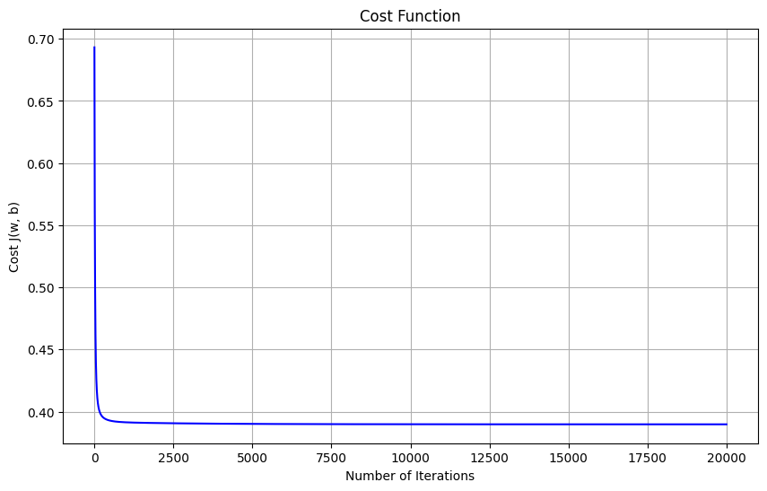

```
Train Set:
Accuracy: 0.8383, Precision: 0.7102, Recall: 0.3154
Intercept (Bias) b:       -1.8062
----------------------------------------
LOAN                      -0.2235
MORTDUE                   -0.1687
VALUE                     0.2084
YOJ                       -0.0692
DEROG                     0.4744
DELINQ                    0.8260
CLAGE                     -0.4606
NINQ                      0.2964
CLNO                      -0.1806
DEBTINC                   0.3706
REASON_HomeImp            0.2801
JOB_Office                -0.4125
JOB_Other                 0.0884
JOB_ProfExe               0.0992
JOB_Sales                 1.1334
JOB_Self                  0.6169

Test Set:
Accuracy: 0.8372, Precision: 0.7374, Recall: 0.3029

 NON-CATEGORICAL FEATURES
```

|  | Feature | Weight | Effect on Default Probability |
| --- | --- | --- | --- |
| 0 | LOAN | -0.2235 | DECREASES |
| 1 | MORTDUE | -0.1687 | DECREASES |
| 2 | VALUE | 0.2084 | INCREASES |
| 3 | YOJ | -0.0692 | DECREASES |
| 4 | DEROG | 0.4744 | INCREASES |
| 5 | DELINQ | 0.8260 | INCREASES |
| 6 | CLAGE | -0.4606 | DECREASES |
| 7 | NINQ | 0.2964 | INCREASES |
| 8 | CLNO | -0.1806 | DECREASES |
| 9 | DEBTINC | 0.3706 | INCREASES |

```
 CATEGORICAL FEATURE JOB
```

|  | Job Category | Weight |
| --- | --- | --- |
| 0 | Reference (dropped) | 0.0000 |
| 1 | Office | -0.4125 |
| 2 | Other | 0.0884 |
| 3 | ProfExe | 0.0992 |
| 4 | Sales | 1.1334 |
| 5 | Self | 0.6169 |

```
 LOWEST PD:  Office (Weight = -0.4125)
 HIGHEST PD: Sales (Weight = 1.1334)

 CATEGORICAL FEATURE REASON
```

|  | Reason Category | Weight |
| --- | --- | --- |
| 0 | Reference (dropped) | 0.0000 |
| 1 | HomeImp | 0.2801 |

```
 LOWEST PD:  Reference (dropped) (Weight = 0.0000)
 HIGHEST PD: HomeImp (Weight = 0.2801)
```

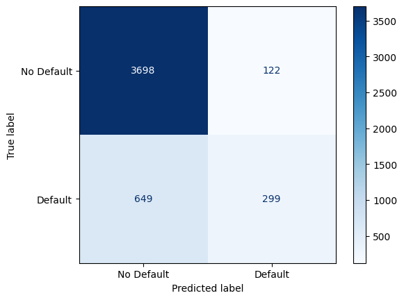

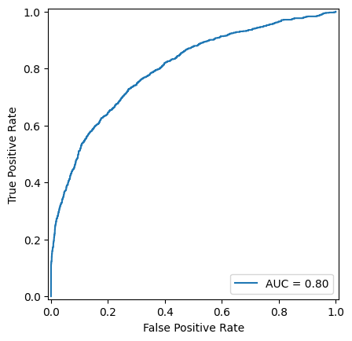

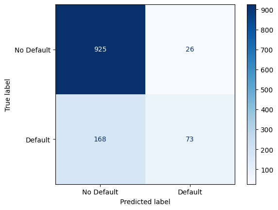

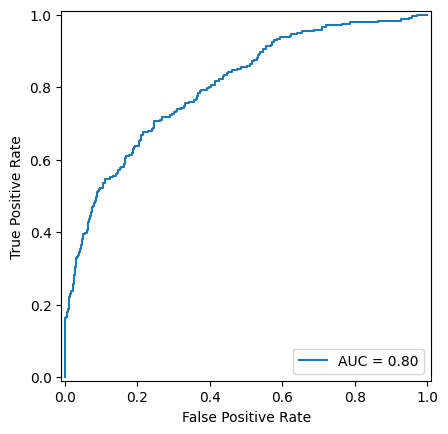

```python
# Exercise 3

class LogisticRegressionManual:
    def __init__(self, learning_rate=0.1, iterations=20000):
        self.lr = learning_rate
        self.iterations = iterations
        self.weights = None
        self.bias = None
        self.cost_history = [] # To store cost at each step

    def _sigmoid(self, z):
        return 1 / (1 + np.exp(-z))

    def _compute_cost(self, y, y_pred):
        m = len(y)
        # Cross entropy loss formula
        cost = -(1/m) * np.sum(y * np.log(y_pred) + (1 - y) * np.log(1 - y_pred))
        return cost

    def fit(self, X, y):
        m, n = X.shape
        self.weights = np.zeros(n)
        self.bias = 0

        for i in range(self.iterations):
            z = np.dot(X, self.weights) + self.bias
            y_pred = self._sigmoid(z)

            cost = self._compute_cost(y, y_pred)
            self.cost_history.append(cost)

            # Gradient calculations
            dw = (1/m) * np.dot(X.T, (y_pred - y))
            db = (1/m) * np.sum(y_pred - y)

            # Parameter updates
            self.weights -= self.lr * dw
            self.bias -= self.lr * db

    def predict_proba(self, X):
          z = np.dot(X, self.weights) + self.bias
          return self._sigmoid(z)

    def predict(self, X, cutoff=0.5):
            z = np.dot(X, self.weights) + self.bias
            y_pred = self._sigmoid(z)
            # Apply the 0.5 cut-off for classification
            return [1 if i > cutoff else 0 for i in y_pred]


model = LogisticRegressionManual(learning_rate=0.1, iterations=20000)
model.fit(X_train, y_train.values)

plt.figure(figsize=(10, 6))
plt.plot(range(len(model.cost_history)), model.cost_history, color="blue")
plt.title("Cost Function")
plt.xlabel("Number of Iterations")
plt.ylabel("Cost J(w, b)")
plt.grid(True)
plt.show()


# 3c) Train
print("\nTrain Set:")

train_probs = model.predict_proba(X_train) # Using the sigmoid function
train_preds = (train_probs >= 0.5).astype(int) # Using 0.5 cut-off

acc = accuracy_score(y_train, train_preds)

prec = precision_score(y_train, train_preds)

rec = recall_score(y_train, train_preds)

print(f"Accuracy: {acc:.4f}, Precision: {prec:.4f}, Recall: {rec:.4f}")

cm = confusion_matrix(y_train, train_preds)

disp = ConfusionMatrixDisplay(confusion_matrix=cm, display_labels=['No Default', 'Default'])
disp.plot(cmap='Blues')

fpr, tpr, thresholds = roc_curve(y_train, train_probs)

roc_auc = auc(fpr, tpr)

roc_display = RocCurveDisplay(fpr=fpr, tpr=tpr, roc_auc=roc_auc)
roc_display.plot()

feature_names = norm_train.drop('BAD', axis=1).columns.tolist()


print(f"{'Intercept (Bias) b:':<25} {model.bias:.4f}")
print("-" * 40)

for name, coef in zip(feature_names, model.weights):
    print(f"{name:<25} {coef:.4f}")

# 3d) Test

print("\nTest Set:")

test_probs = model.predict_proba(X_test) # Using the sigmoid function
test_preds = (test_probs >= 0.5).astype(int) # Using 0.5 cut-off

acc2 = accuracy_score(y_test, test_preds)

prec2 = precision_score(y_test, test_preds)

rec2 = recall_score(y_test, test_preds)

print(f"Accuracy: {acc2:.4f}, Precision: {prec2:.4f}, Recall: {rec2:.4f}")

cm2 = confusion_matrix(y_test, test_preds)

disp = ConfusionMatrixDisplay(confusion_matrix=cm2, display_labels=['No Default', 'Default'])
disp.plot(cmap='Blues')

fpr2, tpr2, thresholds = roc_curve(y_test, test_probs)

roc_auc2 = auc(fpr2, tpr2)

roc_display = RocCurveDisplay(fpr=fpr2, tpr=tpr2, roc_auc=roc_auc2)
roc_display.plot()

# 3e) Feature effects on default probability

non_cat_features = ['LOAN', 'MORTDUE', 'VALUE', 'YOJ', 'DEROG', 'DELINQ', 'CLAGE', 'NINQ', 'CLNO', 'DEBTINC']
non_cat_data = []
for feat in non_cat_features:
    if feat in feature_names:
        idx = feature_names.index(feat)
        weight = model.weights[idx]
        effect = "INCREASES" if weight > 0 else "DECREASES"
        non_cat_data.append([feat, f"{weight:.4f}", effect])

df_non_cat = pd.DataFrame(non_cat_data, columns=['Feature', 'Weight', 'Effect on Default Probability'])
print("\n NON-CATEGORICAL FEATURES ")
display(df_non_cat)

job_features = [f for f in feature_names if 'JOB_' in f]
job_weights_data = []
job_weights_dict = {'Reference (dropped)': 0.0}

for feat in job_features:
    idx = feature_names.index(feat)
    weight = model.weights[idx]
    job_name = feat.replace('JOB_', '')
    job_weights_dict[job_name] = weight
    job_weights_data.append([job_name, f"{weight:.4f}"])

job_weights_data.insert(0, ['Reference (dropped)', '0.0000'])

df_job = pd.DataFrame(job_weights_data, columns=['Job Category', 'Weight'])
print("\n CATEGORICAL FEATURE JOB ")
display(df_job)

if job_weights_dict:
    lowest_job = min(job_weights_dict, key=job_weights_dict.get)
    highest_job = max(job_weights_dict, key=job_weights_dict.get)
    print(f" LOWEST PD:  {lowest_job} (Weight = {job_weights_dict[lowest_job]:.4f})")
    print(f" HIGHEST PD: {highest_job} (Weight = {job_weights_dict[highest_job]:.4f})")


reason_features = [f for f in feature_names if 'REASON_' in f]
reason_weights_data = []
reason_weights_dict = {'Reference (dropped)': 0.0}

for feat in reason_features:
    idx = feature_names.index(feat)
    weight = model.weights[idx]
    reason_name = feat.replace('REASON_', '')
    reason_weights_dict[reason_name] = weight
    reason_weights_data.append([reason_name, f"{weight:.4f}"])

reason_weights_data.insert(0, ['Reference (dropped)', '0.0000'])

df_reason = pd.DataFrame(reason_weights_data, columns=['Reason Category', 'Weight'])
print("\n CATEGORICAL FEATURE REASON")
display(df_reason)

if reason_weights_dict:
    lowest_reason = min(reason_weights_dict, key=reason_weights_dict.get)
    highest_reason = max(reason_weights_dict, key=reason_weights_dict.get)
    print(f" LOWEST PD:  {lowest_reason} (Weight = {reason_weights_dict[lowest_reason]:.4f})")
    print(f" HIGHEST PD: {highest_reason} (Weight = {reason_weights_dict[highest_reason]:.4f})")
```